# Разбор проекта 3 Restaurant Rating prediction

В этом соревновании вам будет предложен датасет, содержащий сведения о ресторанах. С помощью имеющего в вашем распоряжении кода, вам необходимо создать модель, использующую алгоритм RandomForestRegression, которая будет прогнозировать рейтинг ресторана по версии TripAdvidor.

##### Вот по каким критериям проект будет оценивать ментор:

- Качество кода (ясность, соответствие стандартам оформления pep-8, наличие комментариев).
- Наличие визуализации с выводами (корреляция и важность признаков).
- Feature Engineering и обогащение датасета (*Дополнительно: использование внешних источников данных).
- Работа с метрикой МАЕ.

```python
import numpy as np # linear algebra
import pandas as pd # data processing, CSV file I/O (e.g. pd.read_csv)

import matplotlib.pyplot as plt
import seaborn as sns
%matplotlib inline

# Загружаем специальный удобный инструмент для разделения датасета:
from sklearn.model_selection import train_test_split
```

```python
# всегда фиксируйте RANDOM_SEED, чтобы ваши эксперименты были воспроизводимы!
RANDOM_SEED = 42
```

# Первичный осмотр данных

```python
df = pd.read_csv('main_task.csv.xls')
```

```python
df.head()
```

|  | Restaurant_id | City | Cuisine Style | Ranking | Rating | Price Range | Number of Reviews | Reviews | URL_TA | ID_TA |
| --- | --- | --- | --- | --- | --- | --- | --- | --- | --- | --- |
| 0 | id_5569 | Paris | ['European', 'French', 'International'] | 5570.0 | 3.5 | $$ - $$$ | 194.0 | [['Good food at your doorstep', 'A good hotel ... | /Restaurant_Review-g187147-d1912643-Reviews-R_... | d1912643 |
| 1 | id_1535 | Stockholm | NaN | 1537.0 | 4.0 | NaN | 10.0 | [['Unique cuisine', 'Delicious Nepalese food']... | /Restaurant_Review-g189852-d7992032-Reviews-Bu... | d7992032 |
| 2 | id_352 | London | ['Japanese', 'Sushi', 'Asian', 'Grill', 'Veget... | 353.0 | 4.5 | $$$$ | 688.0 | [['Catch up with friends', 'Not exceptional'],... | /Restaurant_Review-g186338-d8632781-Reviews-RO... | d8632781 |
| 3 | id_3456 | Berlin | NaN | 3458.0 | 5.0 | NaN | 3.0 | [[], []] | /Restaurant_Review-g187323-d1358776-Reviews-Es... | d1358776 |
| 4 | id_615 | Munich | ['German', 'Central European', 'Vegetarian Fri... | 621.0 | 4.0 | $$ - $$$ | 84.0 | [['Best place to try a Bavarian food', 'Nice b... | /Restaurant_Review-g187309-d6864963-Reviews-Au... | d6864963 |

```python
df.info()
```

```
<class 'pandas.core.frame.DataFrame'>
RangeIndex: 40000 entries, 0 to 39999
Data columns (total 10 columns):
 #   Column             Non-Null Count  Dtype
---  ------             --------------  -----
 0   Restaurant_id      40000 non-null  object
 1   City               40000 non-null  object
 2   Cuisine Style      30717 non-null  object
 3   Ranking            40000 non-null  float64
 4   Rating             40000 non-null  float64
 5   Price Range        26114 non-null  object
 6   Number of Reviews  37457 non-null  float64
 7   Reviews            40000 non-null  object
 8   URL_TA             40000 non-null  object
 9   ID_TA              40000 non-null  object
dtypes: float64(3), object(7)
memory usage: 3.1+ MB
```

- **Restaurant_id** — идентификационный номер ресторана / сети ресторанов;
- **City — город**, в котором находится ресторан;
- **Cuisine Style** — кухня или кухни, к которым можно отнести блюда, предлагаемые в ресторане;
- **Ranking** — место, которое занимает данный ресторан среди всех ресторанов своего города;
- **Rating** — рейтинг ресторана по данным TripAdvisor (именно это значение должна будет предсказывать модель);
- **Price Range** — диапазон цен в ресторане;
- **Number of Reviews** — количество отзывов о ресторане;
- **Reviews** — данные о двух отзывах, которые отображаются на сайте ресторана;
- **URL_TA** — URL страницы ресторана на TripAdvosor;
- **ID_TA** — идентификатор ресторана в базе данных TripAdvisor.

*Размерность датасета* - 40к строк на 10 колонок

*Сколько строковых переменных?* - 7 строковых переменных

*Сколько числовых переменных?* - 3 числовых переменных

*Нас удовлетворяют типы данных для каждой из колонок?* - Да!

```python
'''
А чего нам долго ждать обучения?

Обучим прямо сейчас и посмотрим, какой скор выходит.
'''

# Импортируем необходимые библиотеки:
from sklearn.ensemble import RandomForestRegressor # инструмент для создания и обучения модели
from sklearn import metrics # инструменты для оценки точности модели

def ML(df):
    y = df.Rating.values # наш таргет
    X = df.drop(['Rating'], axis=1)

    # Воспользуемся специальной функцие train_test_split для разбивки тестовых данных
    # выделим 10% данных на валидацию (параметр test_size)
    X_train, X_test, y_train, y_test = train_test_split(X, y, test_size=0.1, random_state=RANDOM_SEED)

    # Создаём модель (НАСТРОЙКИ НЕ ТРОГАЕМ)
    model = RandomForestRegressor(n_estimators=100, verbose=1, n_jobs=-1, random_state=RANDOM_SEED)

    # Обучаем модель на тестовом наборе данных
    model.fit(X_train, y_train)

    # Используем обученную модель для предсказания рейтинга ресторанов в тестовой выборке.
    # Предсказанные значения записываем в переменную y_pred
    y_pred = model.predict(X_test)

    # Сравниваем предсказанные значения (y_pred) с реальными (y_test), и смотрим насколько они в среднем отличаются
    # Метрика называется Mean Absolute Error (MAE) и показывает среднее отклонение предсказанных значений от фактических.
    print('MAE:', metrics.mean_absolute_error(y_test, y_pred))

    # в RandomForestRegressor есть возможность вывести самые важные признаки для модели
    plt.rcParams['figure.figsize'] = (5,5)
    feat_importances = pd.Series(model.feature_importances_, index=X.columns)
    feat_importances.nlargest(15).plot(kind='barh')
    plt.show()
```

```
[Parallel(n_jobs=-1)]: Using backend ThreadingBackend with 4 concurrent workers.
[Parallel(n_jobs=-1)]: Done  42 tasks      | elapsed:    0.6s
[Parallel(n_jobs=-1)]: Done 100 out of 100 | elapsed:    1.4s finished
[Parallel(n_jobs=4)]: Using backend ThreadingBackend with 4 concurrent workers.
[Parallel(n_jobs=4)]: Done  42 tasks      | elapsed:    0.0s
[Parallel(n_jobs=4)]: Done 100 out of 100 | elapsed:    0.0s finished
```

```
MAE: 0.502575104714453
```

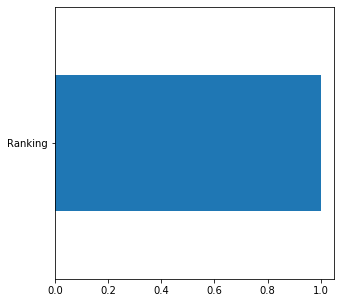

```python
ML(df[['Ranking','Rating']])
```

# Чистка данных и фича инженеринг

## Restaurant_id

```python
print('Как выглядят данные в столбце:', df['Restaurant_id'][0])
print()
print('Какой тип данных:', df['Restaurant_id'].dtypes)
print()
print('Количество пропусков в столбце:', df['Restaurant_id'].isna().sum())
```

```
Как выглядят данные в столбце: id_5569

Какой тип данных: object

Количество пропусков в столбце: 0
```

```python
df.Restaurant_id.describe()
# по условию - в одному id  могут быть прикреплены несколько ресторанов одной сети,
# поэтому уникальных значений меньше чем записей
```

```
count      40000
unique     11909
top       id_633
freq          18
Name: Restaurant_id, dtype: object
```

```python
df.Restaurant_id = [i[3:] for i in df.Restaurant_id]
df.Restaurant_id = [int(i) for i in df.Restaurant_id]
```

```python
print(len(df.Restaurant_id))
print(type(df.Restaurant_id[1]))
# превратили столбец в численное выражение
```

```
40000
<class 'numpy.int64'>
```

Посмотрим, как изменились деперь наши данные, все ли верно:

```python
df.head(3)
```

|  | Restaurant_id | City | Cuisine Style | Ranking | Rating | Price Range | Number of Reviews | Reviews | URL_TA | ID_TA |
| --- | --- | --- | --- | --- | --- | --- | --- | --- | --- | --- |
| 0 | 5569 | Paris | ['European', 'French', 'International'] | 5570.0 | 3.5 | $$ - $$$ | 194.0 | [['Good food at your doorstep', 'A good hotel ... | /Restaurant_Review-g187147-d1912643-Reviews-R_... | d1912643 |
| 1 | 1535 | Stockholm | NaN | 1537.0 | 4.0 | NaN | 10.0 | [['Unique cuisine', 'Delicious Nepalese food']... | /Restaurant_Review-g189852-d7992032-Reviews-Bu... | d7992032 |
| 2 | 352 | London | ['Japanese', 'Sushi', 'Asian', 'Grill', 'Veget... | 353.0 | 4.5 | $$$$ | 688.0 | [['Catch up with friends', 'Not exceptional'],... | /Restaurant_Review-g186338-d8632781-Reviews-RO... | d8632781 |

Сейчас проверим, насколько id ресторана влияет на МЛ обучение:

```
[Parallel(n_jobs=-1)]: Using backend ThreadingBackend with 4 concurrent workers.
[Parallel(n_jobs=-1)]: Done  42 tasks      | elapsed:    1.2s
[Parallel(n_jobs=-1)]: Done 100 out of 100 | elapsed:    2.8s finished
[Parallel(n_jobs=4)]: Using backend ThreadingBackend with 4 concurrent workers.
[Parallel(n_jobs=4)]: Done  42 tasks      | elapsed:    0.0s
[Parallel(n_jobs=4)]: Done 100 out of 100 | elapsed:    0.0s finished
```

```
MAE: 0.4869289490904786
```

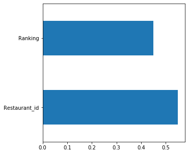

```python
ML(df[['Restaurant_id', 'Ranking','Rating']])
```

Мне (лично) это не очень нравится, складывается ощущение, что машина может запоминать название ресторана и соотвественно из этого предсказывать правильный результат.

Попробуем удалить id из датафрейма, при этом не потеряв ценную информацию.

А информация ценная может быть только в одном - во франшизах.

```python
#Заметим, что у нас вообще-то есть тут повторения, а значит есть и идея - создать колонку с франшизами
#а затем удалить этот столбец :)
df['Restaurant_id'].value_counts()
```

```
633      18
871      18
436      18
227      18
430      17
         ..
12847     1
12510     1
6363      1
6774      1
4076      1
Name: Restaurant_id, Length: 11909, dtype: int64
```

```python
# Создаем дополнительный столбец,
# 0 - не франшиза,
# 1 - франшиза
df['Franchise'] = 0
df.head(1)
```

|  | Restaurant_id | City | Cuisine Style | Ranking | Rating | Price Range | Number of Reviews | Reviews | URL_TA | ID_TA | Franchise |
| --- | --- | --- | --- | --- | --- | --- | --- | --- | --- | --- | --- |
| 0 | 5569 | Paris | ['European', 'French', 'International'] | 5570.0 | 3.5 | $$ - $$$ | 194.0 | [['Good food at your doorstep', 'A good hotel ... | /Restaurant_Review-g187147-d1912643-Reviews-R_... | d1912643 | 0 |

```python
# Поместим весь подсчет value_counts() в отдельный датафрейм
# С помощью этого датафрейма занесем потом значения в df['Franchise']

# Друзья, это максимально не элегантное решение! Знаете как лучше - делайте :))
franchise = df['Restaurant_id'].value_counts().to_frame().reset_index().rename(columns={'index': 'Restaurant_id',
                                                                                        'Restaurant_id': 'count'})
```

```python
# посмотрим насколько все ок
franchise.head()
```

|  | Restaurant_id | count |
| --- | --- | --- |
| 0 | 633 | 18 |
| 1 | 871 | 18 |
| 2 | 436 | 18 |
| 3 | 227 | 18 |
| 4 | 430 | 17 |

```python
for i in range(len(df['Restaurant_id'])):
    if franchise['count'][franchise.index[franchise.Restaurant_id == df['Restaurant_id'][i]][0]] > 1:
        #print(franchise['count'][franchise.index[franchise.Restaurant_id == df['Restaurant_id'][i]][0]])
        df['Franchise'][i] = 1
    else: df['Franchise'][i] = 0
```

```python
df['Franchise'][df.index[df.Restaurant_id == 633][0]]
```

```
1
```

```python
df['Franchise'][df.index[df.Restaurant_id == 12847][0]]
```

```
0
```

```python
df['Franchise'][df.index[df.Restaurant_id == 6363][0]]
```

```
0
```

```python
# посмотрим насколько все ок
df.head()
```

|  | Restaurant_id | City | Cuisine Style | Ranking | Rating | Price Range | Number of Reviews | Reviews | URL_TA | ID_TA | Franchise |
| --- | --- | --- | --- | --- | --- | --- | --- | --- | --- | --- | --- |
| 0 | 5569 | Paris | ['European', 'French', 'International'] | 5570.0 | 3.5 | $$ - $$$ | 194.0 | [['Good food at your doorstep', 'A good hotel ... | /Restaurant_Review-g187147-d1912643-Reviews-R_... | d1912643 | 1 |
| 1 | 1535 | Stockholm | NaN | 1537.0 | 4.0 | NaN | 10.0 | [['Unique cuisine', 'Delicious Nepalese food']... | /Restaurant_Review-g189852-d7992032-Reviews-Bu... | d7992032 | 1 |
| 2 | 352 | London | ['Japanese', 'Sushi', 'Asian', 'Grill', 'Veget... | 353.0 | 4.5 | $$$$ | 688.0 | [['Catch up with friends', 'Not exceptional'],... | /Restaurant_Review-g186338-d8632781-Reviews-RO... | d8632781 | 1 |
| 3 | 3456 | Berlin | NaN | 3458.0 | 5.0 | NaN | 3.0 | [[], []] | /Restaurant_Review-g187323-d1358776-Reviews-Es... | d1358776 | 1 |
| 4 | 615 | Munich | ['German', 'Central European', 'Vegetarian Fri... | 621.0 | 4.0 | $$ - $$$ | 84.0 | [['Best place to try a Bavarian food', 'Nice b... | /Restaurant_Review-g187309-d6864963-Reviews-Au... | d6864963 | 1 |

```
[Parallel(n_jobs=-1)]: Using backend ThreadingBackend with 4 concurrent workers.
[Parallel(n_jobs=-1)]: Done  42 tasks      | elapsed:    0.7s
[Parallel(n_jobs=-1)]: Done 100 out of 100 | elapsed:    1.5s finished
[Parallel(n_jobs=4)]: Using backend ThreadingBackend with 4 concurrent workers.
[Parallel(n_jobs=4)]: Done  42 tasks      | elapsed:    0.0s
[Parallel(n_jobs=4)]: Done 100 out of 100 | elapsed:    0.0s finished
```

```
MAE: 0.4990768116221287
```

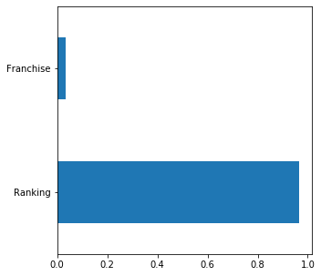

```python
ML(df[['Ranking','Rating', 'Franchise']])
```

```python
a=df.Restaurant_id.value_counts()
a=dict(a)
a=pd.DataFrame({'count':a}, columns=['count'])

A=a.index
B=a.values

df['chain']= df['Restaurant_id'].replace(A, B)
```

```python
df.head()
```

|  | Restaurant_id | City | Cuisine Style | Ranking | Rating | Price Range | Number of Reviews | Reviews | URL_TA | ID_TA | Franchise | chain |
| --- | --- | --- | --- | --- | --- | --- | --- | --- | --- | --- | --- | --- |
| 0 | 5569 | Paris | ['European', 'French', 'International'] | 5570.0 | 3.5 | $$ - $$$ | 194.0 | [['Good food at your doorstep', 'A good hotel ... | /Restaurant_Review-g187147-d1912643-Reviews-R_... | d1912643 | 1 | 3 |
| 1 | 1535 | Stockholm | NaN | 1537.0 | 4.0 | NaN | 10.0 | [['Unique cuisine', 'Delicious Nepalese food']... | /Restaurant_Review-g189852-d7992032-Reviews-Bu... | d7992032 | 1 | 10 |
| 2 | 352 | London | ['Japanese', 'Sushi', 'Asian', 'Grill', 'Veget... | 353.0 | 4.5 | $$$$ | 688.0 | [['Catch up with friends', 'Not exceptional'],... | /Restaurant_Review-g186338-d8632781-Reviews-RO... | d8632781 | 1 | 8 |
| 3 | 3456 | Berlin | NaN | 3458.0 | 5.0 | NaN | 3.0 | [[], []] | /Restaurant_Review-g187323-d1358776-Reviews-Es... | d1358776 | 1 | 4 |
| 4 | 615 | Munich | ['German', 'Central European', 'Vegetarian Fri... | 621.0 | 4.0 | $$ - $$$ | 84.0 | [['Best place to try a Bavarian food', 'Nice b... | /Restaurant_Review-g187309-d6864963-Reviews-Au... | d6864963 | 1 | 14 |

```
[Parallel(n_jobs=-1)]: Using backend ThreadingBackend with 4 concurrent workers.
[Parallel(n_jobs=-1)]: Done  42 tasks      | elapsed:    0.8s
[Parallel(n_jobs=-1)]: Done 100 out of 100 | elapsed:    1.7s finished
[Parallel(n_jobs=4)]: Using backend ThreadingBackend with 4 concurrent workers.
[Parallel(n_jobs=4)]: Done  42 tasks      | elapsed:    0.0s
[Parallel(n_jobs=4)]: Done 100 out of 100 | elapsed:    0.0s finished
```

```
MAE: 0.5069368080316956
```

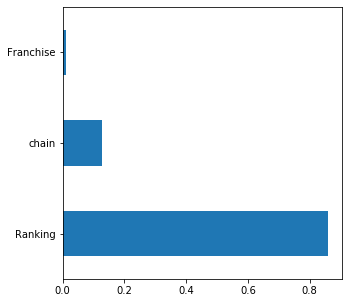

```python
ML(df[['Ranking','Rating', 'Franchise', 'chain']])
```

```
[Parallel(n_jobs=-1)]: Using backend ThreadingBackend with 4 concurrent workers.
[Parallel(n_jobs=-1)]: Done  42 tasks      | elapsed:    1.2s
[Parallel(n_jobs=-1)]: Done 100 out of 100 | elapsed:    2.8s finished
[Parallel(n_jobs=4)]: Using backend ThreadingBackend with 4 concurrent workers.
[Parallel(n_jobs=4)]: Done  42 tasks      | elapsed:    0.0s
[Parallel(n_jobs=4)]: Done 100 out of 100 | elapsed:    0.0s finished
```

```
MAE: 0.48823706251091503
```

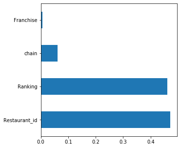

```python
ML(df[['Restaurant_id', 'Ranking','Rating', 'Franchise', 'chain']])
```

```
[Parallel(n_jobs=-1)]: Using backend ThreadingBackend with 4 concurrent workers.
[Parallel(n_jobs=-1)]: Done  42 tasks      | elapsed:    1.2s
[Parallel(n_jobs=-1)]: Done 100 out of 100 | elapsed:    2.8s finished
[Parallel(n_jobs=4)]: Using backend ThreadingBackend with 4 concurrent workers.
[Parallel(n_jobs=4)]: Done  42 tasks      | elapsed:    0.0s
[Parallel(n_jobs=4)]: Done 100 out of 100 | elapsed:    0.0s finished
```

```
MAE: 0.4885622320306592
```

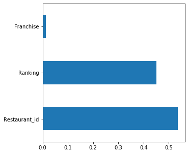

```python
ML(df[['Restaurant_id', 'Ranking','Rating', 'Franchise']])
```

```
[Parallel(n_jobs=-1)]: Using backend ThreadingBackend with 4 concurrent workers.
[Parallel(n_jobs=-1)]: Done  42 tasks      | elapsed:    1.3s
[Parallel(n_jobs=-1)]: Done 100 out of 100 | elapsed:    2.9s finished
[Parallel(n_jobs=4)]: Using backend ThreadingBackend with 4 concurrent workers.
[Parallel(n_jobs=4)]: Done  42 tasks      | elapsed:    0.0s
[Parallel(n_jobs=4)]: Done 100 out of 100 | elapsed:    0.0s finished
```

```
MAE: 0.48818907490815405
```

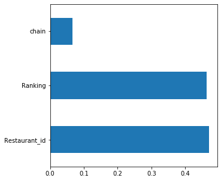

```python
ML(df[['Restaurant_id', 'Ranking','Rating', 'chain']])
```

```
[Parallel(n_jobs=-1)]: Using backend ThreadingBackend with 4 concurrent workers.
[Parallel(n_jobs=-1)]: Done  42 tasks      | elapsed:    0.7s
[Parallel(n_jobs=-1)]: Done 100 out of 100 | elapsed:    1.7s finished
[Parallel(n_jobs=4)]: Using backend ThreadingBackend with 4 concurrent workers.
[Parallel(n_jobs=4)]: Done  42 tasks      | elapsed:    0.0s
[Parallel(n_jobs=4)]: Done 100 out of 100 | elapsed:    0.0s finished
```

```
MAE: 0.5070103547818957
```

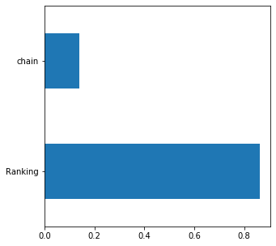

```python
ML(df[['Ranking','Rating', 'chain']])
```

### Итог по Restaurant_id

'Restaurant_id' вместе с 'Rating' : **MAE: 0.4869**

'Restaurant_id', 'Ranking','Rating', 'Franchise' : **MAE: 0.4885**

'Restaurant_id', 'Ranking','Rating', 'chain' : **MAE: 0.4881**

'Restaurant_id', 'Ranking','Rating', 'Franchise', 'chain' : **MAE: 0.4882**

'Ranking','Rating', 'Franchise', 'chain' : **MAE: 0.5069**

'Ranking','Rating', 'Franchise' : **MAE: 0.4990**

'Ranking','Rating', 'chain' : **MAE: 0.5070**

```python
df = df.drop(['Restaurant_id', 'chain'], axis=1)
```

```python
df.head()
```

|  | City | Cuisine Style | Ranking | Rating | Price Range | Number of Reviews | Reviews | URL_TA | ID_TA | Franchise |
| --- | --- | --- | --- | --- | --- | --- | --- | --- | --- | --- |
| 0 | Paris | ['European', 'French', 'International'] | 5570.0 | 3.5 | $$ - $$$ | 194.0 | [['Good food at your doorstep', 'A good hotel ... | /Restaurant_Review-g187147-d1912643-Reviews-R_... | d1912643 | 1 |
| 1 | Stockholm | NaN | 1537.0 | 4.0 | NaN | 10.0 | [['Unique cuisine', 'Delicious Nepalese food']... | /Restaurant_Review-g189852-d7992032-Reviews-Bu... | d7992032 | 1 |
| 2 | London | ['Japanese', 'Sushi', 'Asian', 'Grill', 'Veget... | 353.0 | 4.5 | $$$$ | 688.0 | [['Catch up with friends', 'Not exceptional'],... | /Restaurant_Review-g186338-d8632781-Reviews-RO... | d8632781 | 1 |
| 3 | Berlin | NaN | 3458.0 | 5.0 | NaN | 3.0 | [[], []] | /Restaurant_Review-g187323-d1358776-Reviews-Es... | d1358776 | 1 |
| 4 | Munich | ['German', 'Central European', 'Vegetarian Fri... | 621.0 | 4.0 | $$ - $$$ | 84.0 | [['Best place to try a Bavarian food', 'Nice b... | /Restaurant_Review-g187309-d6864963-Reviews-Au... | d6864963 | 1 |

# City

```python
print('Как выглядят данные в столбце:', df['City'][0])
print()
print('Какой тип данных:', df['City'].dtypes)
print()
print('Количество пропусков в столбце:', df['City'].isna().sum())
```

```
Как выглядят данные в столбце: Paris

Какой тип данных: object

Количество пропусков в столбце: 0
```

```python
df['City'].value_counts()
```

```
London        5757
Paris         4897
Madrid        3108
Barcelona     2734
Berlin        2155
Milan         2133
Rome          2078
Prague        1443
Lisbon        1300
Vienna        1166
Amsterdam     1086
Brussels      1060
Hamburg        949
Munich         893
Lyon           892
Stockholm      820
Budapest       816
Warsaw         727
Dublin         673
Copenhagen     659
Athens         628
Edinburgh      596
Zurich         538
Oporto         513
Geneva         481
Krakow         443
Oslo           385
Helsinki       376
Bratislava     301
Luxembourg     210
Ljubljana      183
Name: City, dtype: int64
```

```python
len(df['City'].value_counts())
```

```
31
```

Дамми-переменные я делать максимально не хочу, поэтому постараемся придумать всевозможные новые признаки, которые полностью бы описывали все города (без упоминания города ИЛИ затем закодировать эти значения)

```python
#Код взяла у Василия Синюрина :)

city_population = {
    'London': 7556900,
    'Paris': 2206488,
    'Madrid': 3155360,
    'Barcelona': 1621537,
    'Berlin': 3326002,
    'Milan': 1331586,
    'Rome': 2864466,
    'Prague': 1294513,
    'Lisbon': 547733,
    'Vienna': 1765649,
    'Amsterdam': 869709,
    'Brussels': 176545,
    'Hamburg': 1739117,
    'Munich': 1456039,
    'Lyon': 496343,
    'Stockholm': 1253309,
    'Budapest': 1741041,
    'Warsaw': 1720398,
    'Dublin': 506211,
    'Copenhagen': 1153615,
    'Athens': 664046,
    'Edinburgh': 482005,
    'Zurich': 402275,
    'Oporto': 221800,
    'Geneva': 196150,
    'Krakow': 762776,
    'Oslo': 673469,
    'Helsinki': 574579,
    'Bratislava': 419700,
    'Luxembourg': 576249,
    'Ljubljana': 277554
}

df["city_population"] = df.City.apply(lambda x: city_population[x])
```

```python
df.head(1)
```

|  | City | Cuisine Style | Ranking | Rating | Price Range | Number of Reviews | Reviews | URL_TA | ID_TA | Franchise | city_population |
| --- | --- | --- | --- | --- | --- | --- | --- | --- | --- | --- | --- |
| 0 | Paris | ['European', 'French', 'International'] | 5570.0 | 3.5 | $$ - $$$ | 194.0 | [['Good food at your doorstep', 'A good hotel ... | /Restaurant_Review-g187147-d1912643-Reviews-R_... | d1912643 | 1 | 2206488 |

```
[Parallel(n_jobs=-1)]: Using backend ThreadingBackend with 4 concurrent workers.
[Parallel(n_jobs=-1)]: Done  42 tasks      | elapsed:    0.8s
[Parallel(n_jobs=-1)]: Done 100 out of 100 | elapsed:    1.7s finished
[Parallel(n_jobs=4)]: Using backend ThreadingBackend with 4 concurrent workers.
[Parallel(n_jobs=4)]: Done  42 tasks      | elapsed:    0.0s
[Parallel(n_jobs=4)]: Done 100 out of 100 | elapsed:    0.0s finished
```

```
MAE: 0.320115
```

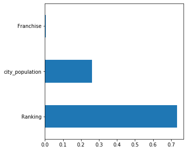

```python
ML(df[['Ranking','Rating', 'Franchise', 'city_population']])
```

```python
#Код взяла у Василия Синюрина :)

capital = {
    'London': 1,
    'Paris': 1,
    'Madrid': 1,
    'Barcelona': 0,
    'Berlin': 1,
    'Milan': 0,
    'Rome': 1,
    'Prague': 1,
    'Lisbon': 1,
    'Vienna': 1,
    'Amsterdam': 1,
    'Brussels': 1,
    'Hamburg': 0,
    'Munich': 0,
    'Lyon': 0,
    'Stockholm': 1,
    'Budapest': 1,
    'Warsaw': 1,
    'Dublin': 1,
    'Copenhagen': 1,
    'Athens': 1,
    'Edinburgh': 0,
    'Zurich': 1,
    'Oporto': 0,
    'Geneva': 1,
    'Krakow': 0,
    'Oslo': 1,
    'Helsinki': 1,
    'Bratislava': 1,
    'Luxembourg': 1,
    'Ljubljana': 1
}

df["capital"] = df['City'].apply(lambda x: capital[x])
```

```python
df.head(1)
```

|  | City | Cuisine Style | Ranking | Rating | Price Range | Number of Reviews | Reviews | URL_TA | ID_TA | Franchise | city_population | capital |
| --- | --- | --- | --- | --- | --- | --- | --- | --- | --- | --- | --- | --- |
| 0 | Paris | ['European', 'French', 'International'] | 5570.0 | 3.5 | $$ - $$$ | 194.0 | [['Good food at your doorstep', 'A good hotel ... | /Restaurant_Review-g187147-d1912643-Reviews-R_... | d1912643 | 1 | 2206488 | 1 |

```python
#Код взяла у Василия Синюрина :)

country = {
    'London': 'UK',
    'Paris': 'FR',
    'Madrid': 'ES',
    'Barcelona': 'ES',
    'Berlin': 'DE',
    'Milan': 'IT',
    'Rome': 'IT',
    'Prague': 'CZ',
    'Lisbon': 'PT',
    'Vienna': 'AT',
    'Amsterdam': 'NL',
    'Brussels': 'BE',
    'Hamburg': 'DE',
    'Munich': 'DE',
    'Lyon': 'FR',
    'Stockholm': 'SE',
    'Budapest': 'HU',
    'Warsaw': 'PL',
    'Dublin': 'IE',
    'Copenhagen': 'DK',
    'Athens': 'GR',
    'Edinburgh': 'UK',
    'Zurich': 'CH',
    'Oporto': 'PT',
    'Geneva': 'CH',
    'Krakow': 'PL',
    'Oslo': 'NO',
    'Helsinki': 'FI',
    'Bratislava': 'SK',
    'Luxembourg': 'LU',
    'Ljubljana': 'SI'
}

df["country"] = df['City'].apply(lambda x: country[x])

print('Ресторанов в стране:')
restaurant_country_counts = df.country.value_counts()
print(restaurant_country_counts)

restaurant_counts = df['City'].value_counts()

df["restaurant_country_counts"] = df.country.apply(
    lambda x: restaurant_country_counts[x])
```

```
Ресторанов в стране:
UK    6353
ES    5842
FR    5789
IT    4211
DE    3997
PT    1813
CZ    1443
PL    1170
AT    1166
NL    1086
BE    1060
CH    1019
SE     820
HU     816
IE     673
DK     659
GR     628
NO     385
FI     376
SK     301
LU     210
SI     183
Name: country, dtype: int64
```

```python
#https://www.bottonline.co.uk/blog/foodie-capitals-of-the-world
# рейтинг городов по количеству присутствующих кухонь в городе
raiting_rest = {
    'London': 2,
    'Paris': 5,
    'Madrid': 16,
    'Barcelona': 25,
    'Berlin': 6,
    'Milan': 28,
    'Rome': 0,
    'Prague': 0,
    'Lisbon': 0,
    'Vienna': 21,
    'Amsterdam': 21,
    'Brussels': 20,
    'Hamburg': 0,
    'Munich': 29,
    'Lyon': 0,
    'Stockholm': 0,
    'Budapest': 0,
    'Warsaw': 0,
    'Dublin': 0,
    'Copenhagen': 0,
    'Athens': 0,
    'Edinburgh': 0,
    'Zurich': 0,
    'Oporto': 0,
    'Geneva': 0,
    'Krakow': 0,
    'Oslo': 0,
    'Helsinki': 0,
    'Bratislava': 0,
    'Luxembourg': 0,
    'Ljubljana': 0
}

df["raiting_rest"] = df['City'].apply(lambda x: raiting_rest[x])
```

```python
df.head()
```

|  | City | Cuisine Style | Ranking | Rating | Price Range | Number of Reviews | Reviews | URL_TA | ID_TA | Franchise | city_population | capital | country | restaurant_country_counts | raiting_rest |
| --- | --- | --- | --- | --- | --- | --- | --- | --- | --- | --- | --- | --- | --- | --- | --- |
| 0 | Paris | ['European', 'French', 'International'] | 5570.0 | 3.5 | $$ - $$$ | 194.0 | [['Good food at your doorstep', 'A good hotel ... | /Restaurant_Review-g187147-d1912643-Reviews-R_... | d1912643 | 1 | 2206488 | 1 | FR | 5789 | 5 |
| 1 | Stockholm | NaN | 1537.0 | 4.0 | NaN | 10.0 | [['Unique cuisine', 'Delicious Nepalese food']... | /Restaurant_Review-g189852-d7992032-Reviews-Bu... | d7992032 | 1 | 1253309 | 1 | SE | 820 | 0 |
| 2 | London | ['Japanese', 'Sushi', 'Asian', 'Grill', 'Veget... | 353.0 | 4.5 | $$$$ | 688.0 | [['Catch up with friends', 'Not exceptional'],... | /Restaurant_Review-g186338-d8632781-Reviews-RO... | d8632781 | 1 | 7556900 | 1 | UK | 6353 | 2 |
| 3 | Berlin | NaN | 3458.0 | 5.0 | NaN | 3.0 | [[], []] | /Restaurant_Review-g187323-d1358776-Reviews-Es... | d1358776 | 1 | 3326002 | 1 | DE | 3997 | 6 |
| 4 | Munich | ['German', 'Central European', 'Vegetarian Fri... | 621.0 | 4.0 | $$ - $$$ | 84.0 | [['Best place to try a Bavarian food', 'Nice b... | /Restaurant_Review-g187309-d6864963-Reviews-Au... | d6864963 | 1 | 1456039 | 0 | DE | 3997 | 29 |

```python
raiting_tourism = {
    'London': 3,
    'Paris':6,
    'Madrid': 47,
    'Barcelona': 33,
    'Berlin': 41,
    'Milan': 35,
    'Rome': 16,
    'Prague': 22,
    'Lisbon': 63,
    'Vienna': 37,
    'Amsterdam': 25,
    'Brussels': 60,
    'Hamburg': 0,
    'Munich': 56,
    'Lyon': 0,
    'Stockholm': 88,
    'Budapest': 62,
    'Warsaw': 74,
    'Dublin': 50,
    'Copenhagen': 71,
    'Athens': 43,
    'Edinburgh': 0,
    'Zurich': 0,
    'Oporto': 0,
    'Geneva': 0,
    'Krakow': 83,
    'Oslo': 0,
    'Helsinki': 0,
    'Bratislava': 0,
    'Luxembourg': 0,
    'Ljubljana': 0
}

df["raiting_tour"] = df['City'].apply(lambda x: raiting_tourism[x])
```

```python
df.head()
```

|  | City | Cuisine Style | Ranking | Rating | Price Range | Number of Reviews | Reviews | URL_TA | ID_TA | Franchise | city_population | capital | country | restaurant_country_counts | raiting_rest | raiting_tour |
| --- | --- | --- | --- | --- | --- | --- | --- | --- | --- | --- | --- | --- | --- | --- | --- | --- |
| 0 | Paris | ['European', 'French', 'International'] | 5570.0 | 3.5 | $$ - $$$ | 194.0 | [['Good food at your doorstep', 'A good hotel ... | /Restaurant_Review-g187147-d1912643-Reviews-R_... | d1912643 | 1 | 2206488 | 1 | FR | 5789 | 5 | 6 |
| 1 | Stockholm | NaN | 1537.0 | 4.0 | NaN | 10.0 | [['Unique cuisine', 'Delicious Nepalese food']... | /Restaurant_Review-g189852-d7992032-Reviews-Bu... | d7992032 | 1 | 1253309 | 1 | SE | 820 | 0 | 88 |
| 2 | London | ['Japanese', 'Sushi', 'Asian', 'Grill', 'Veget... | 353.0 | 4.5 | $$$$ | 688.0 | [['Catch up with friends', 'Not exceptional'],... | /Restaurant_Review-g186338-d8632781-Reviews-RO... | d8632781 | 1 | 7556900 | 1 | UK | 6353 | 2 | 3 |
| 3 | Berlin | NaN | 3458.0 | 5.0 | NaN | 3.0 | [[], []] | /Restaurant_Review-g187323-d1358776-Reviews-Es... | d1358776 | 1 | 3326002 | 1 | DE | 3997 | 6 | 41 |
| 4 | Munich | ['German', 'Central European', 'Vegetarian Fri... | 621.0 | 4.0 | $$ - $$$ | 84.0 | [['Best place to try a Bavarian food', 'Nice b... | /Restaurant_Review-g187309-d6864963-Reviews-Au... | d6864963 | 1 | 1456039 | 0 | DE | 3997 | 29 | 56 |

Кодируем все признаки (превращаем все в числа)

```python
from sklearn import preprocessing

le = preprocessing.LabelEncoder()
le.fit(df['City'])
```

```
LabelEncoder()
```

```python
list(le.classes_)
```

```
['Amsterdam',
 'Athens',
 'Barcelona',
 'Berlin',
 'Bratislava',
 'Brussels',
 'Budapest',
 'Copenhagen',
 'Dublin',
 'Edinburgh',
 'Geneva',
 'Hamburg',
 'Helsinki',
 'Krakow',
 'Lisbon',
 'Ljubljana',
 'London',
 'Luxembourg',
 'Lyon',
 'Madrid',
 'Milan',
 'Munich',
 'Oporto',
 'Oslo',
 'Paris',
 'Prague',
 'Rome',
 'Stockholm',
 'Vienna',
 'Warsaw',
 'Zurich']
```

```python
print('Paris:', le.transform(['Paris'])[0])

city = df['City'].to_frame()
city_le = city.apply(preprocessing.LabelEncoder().fit_transform)
df['City'] = city_le

country = df['country'].to_frame()
country_le = country.apply(preprocessing.LabelEncoder().fit_transform)
df['country'] = country_le
```

```
Paris: 24
```

```python
#Код взяла у Василия Синюрина :)

#print('Количество ресторанов в городе:')
restaurant_counts = df.City.value_counts()
#print(restaurant_counts)
df["restaurant_counts"] = df.City.apply(lambda x: restaurant_counts[x])
df["rest_density"] = df.restaurant_counts / df.city_population
```

```python
df.head(3)
```

|  | City | Cuisine Style | Ranking | Rating | Price Range | Number of Reviews | Reviews | URL_TA | ID_TA | Franchise | city_population | capital | country | restaurant_country_counts | raiting_rest | raiting_tour | restaurant_counts | rest_density |
| --- | --- | --- | --- | --- | --- | --- | --- | --- | --- | --- | --- | --- | --- | --- | --- | --- | --- | --- |
| 0 | 24 | ['European', 'French', 'International'] | 5570.0 | 3.5 | $$ - $$$ | 194.0 | [['Good food at your doorstep', 'A good hotel ... | /Restaurant_Review-g187147-d1912643-Reviews-R_... | d1912643 | 1 | 2206488 | 1 | 8 | 5789 | 5 | 6 | 4897 | 0.002219 |
| 1 | 27 | NaN | 1537.0 | 4.0 | NaN | 10.0 | [['Unique cuisine', 'Delicious Nepalese food']... | /Restaurant_Review-g189852-d7992032-Reviews-Bu... | d7992032 | 1 | 1253309 | 1 | 18 | 820 | 0 | 88 | 820 | 0.000654 |
| 2 | 16 | ['Japanese', 'Sushi', 'Asian', 'Grill', 'Veget... | 353.0 | 4.5 | $$$$ | 688.0 | [['Catch up with friends', 'Not exceptional'],... | /Restaurant_Review-g186338-d8632781-Reviews-RO... | d8632781 | 1 | 7556900 | 1 | 21 | 6353 | 2 | 3 | 5757 | 0.000762 |

```
[Parallel(n_jobs=-1)]: Using backend ThreadingBackend with 4 concurrent workers.
[Parallel(n_jobs=-1)]: Done  42 tasks      | elapsed:    1.4s
[Parallel(n_jobs=-1)]: Done 100 out of 100 | elapsed:    3.6s finished
[Parallel(n_jobs=4)]: Using backend ThreadingBackend with 4 concurrent workers.
[Parallel(n_jobs=4)]: Done  42 tasks      | elapsed:    0.0s
[Parallel(n_jobs=4)]: Done 100 out of 100 | elapsed:    0.0s finished
```

```
MAE: 0.3174675
```

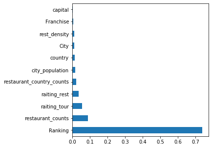

```python
ML(df[['City', 'Ranking','Rating', 'Franchise', 'city_population', 'capital',
       'country', 'restaurant_country_counts',
       'raiting_rest',
       'raiting_tour',
      'restaurant_counts',
      'rest_density']])
```

Был **MAE: 0.3201**

Стал **MAE: 0.3174**

# Cuisine Style

```python
print('Как выглядят данные в столбце:', df['Cuisine Style'][0])
print()
print('Какой тип данных:', df['Cuisine Style'].dtypes)
print()
print('Количество пропусков в столбце:', df['Cuisine Style'].isna().sum())
```

```
Как выглядят данные в столбце: ['European', 'French', 'International']

Какой тип данных: object

Количество пропусков в столбце: 9283
```

```python
df.head()
```

|  | City | Cuisine Style | Ranking | Rating | Price Range | Number of Reviews | Reviews | URL_TA | ID_TA | Franchise | city_population | capital | country | restaurant_country_counts | raiting_rest | raiting_tour | restaurant_counts | rest_density |
| --- | --- | --- | --- | --- | --- | --- | --- | --- | --- | --- | --- | --- | --- | --- | --- | --- | --- | --- |
| 0 | 24 | ['European', 'French', 'International'] | 5570.0 | 3.5 | $$ - $$$ | 194.0 | [['Good food at your doorstep', 'A good hotel ... | /Restaurant_Review-g187147-d1912643-Reviews-R_... | d1912643 | 1 | 2206488 | 1 | 8 | 5789 | 5 | 6 | 4897 | 0.002219 |
| 1 | 27 | NaN | 1537.0 | 4.0 | NaN | 10.0 | [['Unique cuisine', 'Delicious Nepalese food']... | /Restaurant_Review-g189852-d7992032-Reviews-Bu... | d7992032 | 1 | 1253309 | 1 | 18 | 820 | 0 | 88 | 820 | 0.000654 |
| 2 | 16 | ['Japanese', 'Sushi', 'Asian', 'Grill', 'Veget... | 353.0 | 4.5 | $$$$ | 688.0 | [['Catch up with friends', 'Not exceptional'],... | /Restaurant_Review-g186338-d8632781-Reviews-RO... | d8632781 | 1 | 7556900 | 1 | 21 | 6353 | 2 | 3 | 5757 | 0.000762 |
| 3 | 3 | NaN | 3458.0 | 5.0 | NaN | 3.0 | [[], []] | /Restaurant_Review-g187323-d1358776-Reviews-Es... | d1358776 | 1 | 3326002 | 1 | 4 | 3997 | 6 | 41 | 2155 | 0.000648 |
| 4 | 21 | ['German', 'Central European', 'Vegetarian Fri... | 621.0 | 4.0 | $$ - $$$ | 84.0 | [['Best place to try a Bavarian food', 'Nice b... | /Restaurant_Review-g187309-d6864963-Reviews-Au... | d6864963 | 1 | 1456039 | 0 | 4 | 3997 | 29 | 56 | 893 | 0.000613 |

```python
df['Cuisine Style'].value_counts()
```

```
['Italian']                                                                     1032
['French']                                                                       805
['Spanish']                                                                      695
['French', 'European']                                                           405
['Cafe']                                                                         403
                                                                                ...
['Mexican', 'Latin', 'Spanish', 'South American', 'Peruvian']                      1
['Italian', 'European', 'Pizza', 'Vegetarian Friendly', 'Kosher']                  1
['Steakhouse', 'Barbecue', 'International']                                        1
['Pizza', 'Italian', 'Mediterranean', 'Wine Bar']                                  1
['Italian', 'American', 'Peruvian', 'European', 'Spanish', 'South American']       1
Name: Cuisine Style, Length: 9007, dtype: int64
```

```python
df['Cuisine Style'].fillna('None', inplace=True)
new = pd.DataFrame(df['Cuisine Style'].dropna())
a = list(new['Cuisine Style'])
b = list()

def l(x):
    i = 0
    for g in x:
        f = x[i].split(',')
        v = 0
        for g in f:
            h = f[v][2:-1].replace("'", '')
            v = +1
            b.append(h)
        i += 1

l(a)

from collections import Counter

coun=Counter(b)
coun=dict(coun)
coun=pd.DataFrame({'count':coun}, columns=['count'])
a=coun['count'].mean()

b=list(coun.query('count > @a').index)[:-1]
b

#оставляем только самые популярные кухни

def find_item(cell):
    if item in cell:
        return 1
    return 0


for item in b:
    df[item] = df['Cuisine Style'].apply(find_item)

#data['Cuisine_Style'] = data['Cuisine_Style'].apply(lambda x: len(x))
```

```python
# df['Cuisine Style'].fillna('None', inplace=True)
i = 0
for x in df['Cuisine Style']:
    x = x.split(',')
    df['Cuisine Style'][i] = x
    i+=1
df['Quan_cuis'] = df['Cuisine Style'].apply(lambda x: len(x))
```

```python
for i in range(len(df['Cuisine Style'])):
    if df['Cuisine Style'][i][0] == 'None':
        df['Quan_cuis'][i] = 0
```

```python
df.head()
```

|  | City | Cuisine Style | Ranking | Rating | Price Range | Number of Reviews | Reviews | URL_TA | ID_TA | Franchise | ... | Japanese | Mediterranean | Pizza | Pub | Seafood | Spanish | Sushi | Thai | Vegetarian Friendly | Quan_cuis |
| --- | --- | --- | --- | --- | --- | --- | --- | --- | --- | --- | --- | --- | --- | --- | --- | --- | --- | --- | --- | --- | --- |
| 0 | 24 | [['European', 'French', 'International']] | 5570.0 | 3.5 | $$ - $$$ | 194.0 | [['Good food at your doorstep', 'A good hotel ... | /Restaurant_Review-g187147-d1912643-Reviews-R_... | d1912643 | 1 | ... | 0 | 0 | 0 | 0 | 0 | 0 | 0 | 0 | 0 | 3 |
| 1 | 27 | [None] | 1537.0 | 4.0 | NaN | 10.0 | [['Unique cuisine', 'Delicious Nepalese food']... | /Restaurant_Review-g189852-d7992032-Reviews-Bu... | d7992032 | 1 | ... | 0 | 0 | 0 | 0 | 0 | 0 | 0 | 0 | 0 | 0 |
| 2 | 16 | [['Japanese', 'Sushi', 'Asian', 'Grill', '... | 353.0 | 4.5 | $$$$ | 688.0 | [['Catch up with friends', 'Not exceptional'],... | /Restaurant_Review-g186338-d8632781-Reviews-RO... | d8632781 | 1 | ... | 1 | 0 | 0 | 0 | 0 | 0 | 1 | 0 | 1 | 7 |
| 3 | 3 | [None] | 3458.0 | 5.0 | NaN | 3.0 | [[], []] | /Restaurant_Review-g187323-d1358776-Reviews-Es... | d1358776 | 1 | ... | 0 | 0 | 0 | 0 | 0 | 0 | 0 | 0 | 0 | 0 |
| 4 | 21 | [['German', 'Central European', 'Vegetarian ... | 621.0 | 4.0 | $$ - $$$ | 84.0 | [['Best place to try a Bavarian food', 'Nice b... | /Restaurant_Review-g187309-d6864963-Reviews-Au... | d6864963 | 1 | ... | 0 | 0 | 0 | 0 | 0 | 0 | 0 | 0 | 1 | 3 |

5 rows × 40 columns

```python
df.info()
```

```
<class 'pandas.core.frame.DataFrame'>
RangeIndex: 40000 entries, 0 to 39999
Data columns (total 40 columns):
 #   Column                     Non-Null Count  Dtype
---  ------                     --------------  -----
 0   City                       40000 non-null  int64
 1   Cuisine Style              40000 non-null  object
 2   Ranking                    40000 non-null  float64
 3   Rating                     40000 non-null  float64
 4   Price Range                26114 non-null  object
 5   Number of Reviews          37457 non-null  float64
 6   Reviews                    40000 non-null  object
 7   URL_TA                     40000 non-null  object
 8   ID_TA                      40000 non-null  object
 9   Franchise                  40000 non-null  int64
```

[output cut: 32 more lines]

```
[Parallel(n_jobs=-1)]: Using backend ThreadingBackend with 4 concurrent workers.
[Parallel(n_jobs=-1)]: Done  42 tasks      | elapsed:    2.6s
[Parallel(n_jobs=-1)]: Done 100 out of 100 | elapsed:    6.1s finished
[Parallel(n_jobs=4)]: Using backend ThreadingBackend with 4 concurrent workers.
[Parallel(n_jobs=4)]: Done  42 tasks      | elapsed:    0.0s
[Parallel(n_jobs=4)]: Done 100 out of 100 | elapsed:    0.0s finished
```

```
MAE: 0.28805499999999995
```

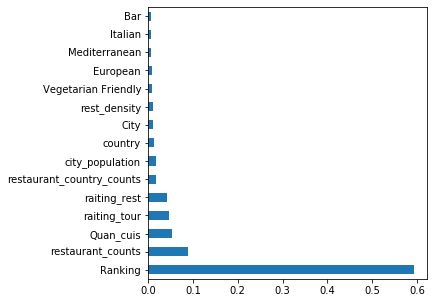

```python
ML(df[['City', 'Ranking','Rating', 'Franchise', 'city_population', 'capital',
       'country', 'restaurant_country_counts',
       'raiting_rest',
       'raiting_tour',
      'restaurant_counts',
      'rest_density',
       'American',
       'Asian',
       'Bar',
       'British',
       'Cafe',
       'Chinese',
       'European',
       'Fast Food',
       'French',
       'Indian',
       'International',
       'Italian',
       'Japanese',
       'Mediterranean',
       'Pizza',
       'Pub',
       'Seafood',
       'Spanish',
       'Sushi',
       'Thai',
       'Vegetarian Friendly',
      'Quan_cuis']])
```

Был **MAE: 0.3174**

Стал **MAE: 0.2880**

```python
df = df.drop(['Cuisine Style', 'URL_TA', 'ID_TA'], axis=1)
```

```python
df.head()
```

|  | City | Ranking | Rating | Price Range | Number of Reviews | Reviews | Franchise | city_population | capital | country | ... | Japanese | Mediterranean | Pizza | Pub | Seafood | Spanish | Sushi | Thai | Vegetarian Friendly | Quan_cuis |
| --- | --- | --- | --- | --- | --- | --- | --- | --- | --- | --- | --- | --- | --- | --- | --- | --- | --- | --- | --- | --- | --- |
| 0 | 24 | 5570.0 | 3.5 | $$ - $$$ | 194.0 | [['Good food at your doorstep', 'A good hotel ... | 1 | 2206488 | 1 | 8 | ... | 0 | 0 | 0 | 0 | 0 | 0 | 0 | 0 | 0 | 3 |
| 1 | 27 | 1537.0 | 4.0 | NaN | 10.0 | [['Unique cuisine', 'Delicious Nepalese food']... | 1 | 1253309 | 1 | 18 | ... | 0 | 0 | 0 | 0 | 0 | 0 | 0 | 0 | 0 | 0 |
| 2 | 16 | 353.0 | 4.5 | $$$$ | 688.0 | [['Catch up with friends', 'Not exceptional'],... | 1 | 7556900 | 1 | 21 | ... | 1 | 0 | 0 | 0 | 0 | 0 | 1 | 0 | 1 | 7 |
| 3 | 3 | 3458.0 | 5.0 | NaN | 3.0 | [[], []] | 1 | 3326002 | 1 | 4 | ... | 0 | 0 | 0 | 0 | 0 | 0 | 0 | 0 | 0 | 0 |
| 4 | 21 | 621.0 | 4.0 | $$ - $$$ | 84.0 | [['Best place to try a Bavarian food', 'Nice b... | 1 | 1456039 | 0 | 4 | ... | 0 | 0 | 0 | 0 | 0 | 0 | 0 | 0 | 1 | 3 |

5 rows × 37 columns

# Price Range

```python
df['Price Range'] = df['Price Range'].replace('$', 1)
df['Price Range'] = df['Price Range'].replace('$$ - $$$', 2)
df['Price Range'] = df['Price Range'].replace('$$$$', 3)

a = df['Price Range'].mean()
a = int(a)
df['Price Range'] = df['Price Range'].fillna(a)
```

```python
df.head()
```

|  | City | Ranking | Rating | Price Range | Number of Reviews | Reviews | Franchise | city_population | capital | country | ... | Japanese | Mediterranean | Pizza | Pub | Seafood | Spanish | Sushi | Thai | Vegetarian Friendly | Quan_cuis |
| --- | --- | --- | --- | --- | --- | --- | --- | --- | --- | --- | --- | --- | --- | --- | --- | --- | --- | --- | --- | --- | --- |
| 0 | 24 | 5570.0 | 3.5 | 2.0 | 194.0 | [['Good food at your doorstep', 'A good hotel ... | 1 | 2206488 | 1 | 8 | ... | 0 | 0 | 0 | 0 | 0 | 0 | 0 | 0 | 0 | 3 |
| 1 | 27 | 1537.0 | 4.0 | 1.0 | 10.0 | [['Unique cuisine', 'Delicious Nepalese food']... | 1 | 1253309 | 1 | 18 | ... | 0 | 0 | 0 | 0 | 0 | 0 | 0 | 0 | 0 | 0 |
| 2 | 16 | 353.0 | 4.5 | 3.0 | 688.0 | [['Catch up with friends', 'Not exceptional'],... | 1 | 7556900 | 1 | 21 | ... | 1 | 0 | 0 | 0 | 0 | 0 | 1 | 0 | 1 | 7 |
| 3 | 3 | 3458.0 | 5.0 | 1.0 | 3.0 | [[], []] | 1 | 3326002 | 1 | 4 | ... | 0 | 0 | 0 | 0 | 0 | 0 | 0 | 0 | 0 | 0 |
| 4 | 21 | 621.0 | 4.0 | 2.0 | 84.0 | [['Best place to try a Bavarian food', 'Nice b... | 1 | 1456039 | 0 | 4 | ... | 0 | 0 | 0 | 0 | 0 | 0 | 0 | 0 | 1 | 3 |

5 rows × 37 columns

# Number of Reviews

```python
df['Number of Reviews'] = df['Number of Reviews'].fillna(0)
```

```
[Parallel(n_jobs=-1)]: Using backend ThreadingBackend with 4 concurrent workers.
[Parallel(n_jobs=-1)]: Done  42 tasks      | elapsed:    3.0s
[Parallel(n_jobs=-1)]: Done 100 out of 100 | elapsed:    7.0s finished
[Parallel(n_jobs=4)]: Using backend ThreadingBackend with 4 concurrent workers.
[Parallel(n_jobs=4)]: Done  42 tasks      | elapsed:    0.0s
[Parallel(n_jobs=4)]: Done 100 out of 100 | elapsed:    0.0s finished
```

```
MAE: 0.20492125
```

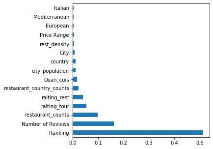

```python
ML(df[['City', 'Ranking','Rating', 'Price Range', 'Number of Reviews', 'Franchise', 'city_population', 'capital',
       'country', 'restaurant_country_counts',
       'raiting_rest',
       'raiting_tour',
      'restaurant_counts',
      'rest_density',
       'American',
       'Asian',
       'Bar',
       'British',
       'Cafe',
       'Chinese',
       'European',
       'Fast Food',
       'French',
       'Indian',
       'International',
       'Italian',
       'Japanese',
       'Mediterranean',
       'Pizza',
       'Pub',
       'Seafood',
       'Spanish',
       'Sushi',
       'Thai',
       'Vegetarian Friendly',
      'Quan_cuis']])
```

Был **MAE: 0.2880**

Стал **MAE: 0.2049**

# Какие еще фичи можно сформировать из всего нашего датасета?

- франшиза или нет
- цена - дорого, дешево, средне заменить на 1,2,3
- посмотреть характерную цену для города(страны) в целом: насколько дорогой город(страна)
- вытащить разницу в днях между отзывами
- посмотреть, сколько слов в отзыве
- дата в отзыве (время между отзывами, время между последним отзывом и сегодня, год последнего отзыва, день недели последнего отзыва)
- посмотреть тональность отзыва
- количество отзывов о ресторане
- количество отзывов в принципе в городе
- города в которых находятся рестораны
- численность городов (улучшается)
- показатель турпотока
- частота вхождений города
- страны
- рейтинг ресторанного бизнеса по городам
- кол-во ресторанов в городе
- плотность ресторана на 1 человека
- является ли город столицей?
- кол-во ресторанов в стране
- коэффициент сосредоточенности ресторанов в городах страны
- кол-во кухонь в ресторане
- средний рейтинг ресторана по городу
- выделить основные кухни и распределить все по ним
- веган френдли? хелфи? глютен фри? фаст фуд? алкоголь есть?

# Теоретическая часть

### 1 Насколько точны прогнозы модели?

**Что такое метрика и зачем она нужна?** Метрика помогает оценить качество работы вашей МЛ модели.

Вам придется подбирать метрики самостоятельно, исходя из условия вашей задачи, вашего датасета и тд.

[1] *Хорошая [статья](https://habr.com/ru/company/ods/blog/328372/) на Хабре про метрики в общем и как их выбрать*

[2] *Еще одна хорошая [статья](http://blog.datalytica.ru/2018/05/blog-post.html)*

[3] *Хороший математический [сайт](http://www.machinelearning.ru/wiki/) о машинном обучении*

[4] *Чем MAE отличается от RMSE на [Medium](https://medium.com/human-in-a-machine-world/mae-and-rmse-which-metric-is-better-e60ac3bde13d)*

Текст взят с сайта [2]

- **Классификация (classification)**: У вас есть ограниченное количество ответов - метки класса (class label). Ваша модель относит данные к какому-либо классу. Например болен-не болен.
  - Confusion Matrix
  - Accuracy Metric
  - Recall/Sensitivity Metric
  - Precision Metric
  - F1 score
- **Регрессия (regression)**: Предсказывает какое-либо число или числовой вектор (например, завтра будет такая-то температура)
  - Mean Absolute Error (MAE)
  - Mean Squared Error (MSE)
  - Root Mean Squared Error (RMSE)
- **Ранжирование (learning to rank)**: Модель будет предсказывать порядок элементов. Например, нам дали учебный класс и мы должны проранжировать учеников по росту, то есть, упорядочить их от самого высокого, до самого низкого.
  - Простая метрика
  - Kendall’s tau

Важно читать про каждую метрику и понимать ее недостатки. Например, `Accuracy Metric` нельзя использовать при несбалансированных классах!

В вашем задании вам предложена метрика **MAE: Mean Absolute Error**

$$MAE = \frac{1}{n} \sum{|y - \hat{y}|} $$

-среднее абсолютное значение отклонения предсказанных значений от фактических, где $y$ - реальное значение переменной, $\hat{y}$ - предсказанное значение вашей моделью

### 2 Переводим категориальные значения в числовые

Под категориальным значением мы будем понимать признак, значения которого означают принадлежность объекта к одной или нескольким категориям. Например, марка автомобиля (одна категория), цвет или цвета (одна или несколько категорий).

- **Фиктивная переменная (англ. dummy variable)** — качественная переменная, принимающая значения 0 и 1, включаемая в эконометрическую модель для учёта влияния качественных признаков и событий на объясняемую переменную. [Почитать поподробнее](https://ru.wikipedia.org/wiki/Фиктивная_переменная)
- **LabelEncoder** -- Например, у нас есть колонка, в которой содержится ограниченный набор строковых параметров (кошечки, собачки, попугайчики). Каждому параметру мы сопоставляем число: 1 - кошечки, 2 - собачки, 3 - попугайчики. Таким образом, наша колонка содержит уже не строковые переменные, а числа (1,2,3).

[ссылка на функцию](https://scikit-learn.org/stable/modules/generated/sklearn.preprocessing.LabelEncoder.html)

- **One-Hot Encoding** - Кодирование категориальных объектов в виде одномерного числового массива.

*Пример:*

У нас есть словарь слов (кошечки, собачки, попугайчики).

Мы берем каждое слово и сопостовляем этому слову вектор (т.е. как бы кодируем его):

- кошечки - [1 0 0]
- собачки - [0 1 0]
- попугайчики - [0 0 1]

Внимание! Длина вектора = длине словаря (Поэтому если у вас 1млн уникальных слов, то лучше OHE не пользоваться :) )

[ссылка на функцию](https://scikit-learn.org/stable/modules/generated/sklearn.preprocessing.OneHotEncoder.html)

[Про работу с категориальными признаками и OHE в частности](https://habr.com/ru/company/ods/blog/326418/#rabota-s-kategorialnymi-priznakami-label-encoding-one-hot-encoding-hashing-trick)

[LabelEncoder и OHE, чем отличается?](https://habr.com/ru/post/456294/)

(Владимир Юшманов)

### 3 PCA (Метод главный компонент)

- один из основных способов уменьшить размерность данных, потеряв наименьшее количество информации

[Прочитать про PCA](https://ru.wikipedia.org/wiki/Метод_главных_компонент)

[Как работает простым языком](https://habr.com/ru/post/304214/)

[Как нам может быть полезен PCA](https://scikit-learn.org/stable/auto_examples/decomposition/plot_incremental_pca.html#sphx-glr-auto-examples-decomposition-plot-incremental-pca-py)

[Тоже самое, но для 3д](https://scikit-learn.org/stable/auto_examples/decomposition/plot_pca_iris.html)